# MLR: Model Checking

## Toolkit

For model diagnostics, the `car` package is particularly useful:

```r
library(car)
```

## Assessing model assumptions

## CAUTION: Residuals in MLR

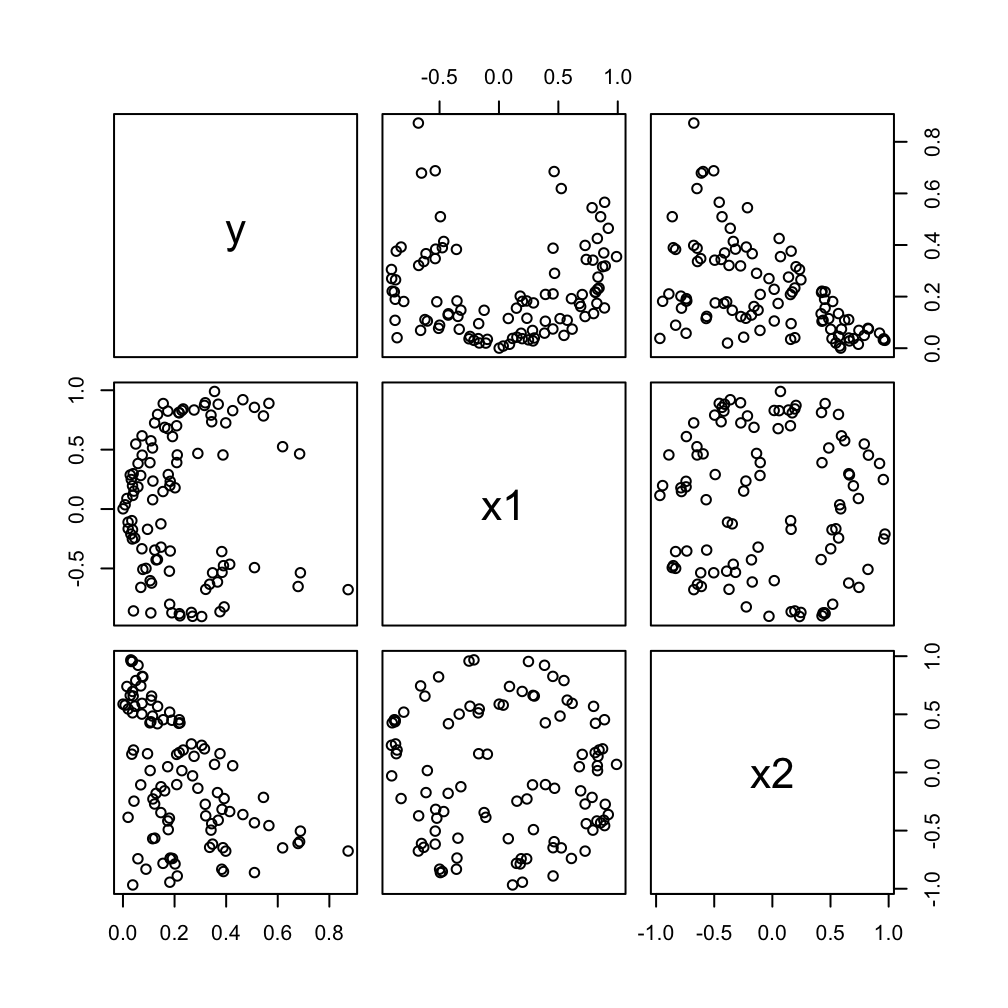

## CAUTION: Residuals in MLR

When there are many regressors in a model, we cannot necessarily associate shapes in a residual plot with a particular problem with the assumptions.

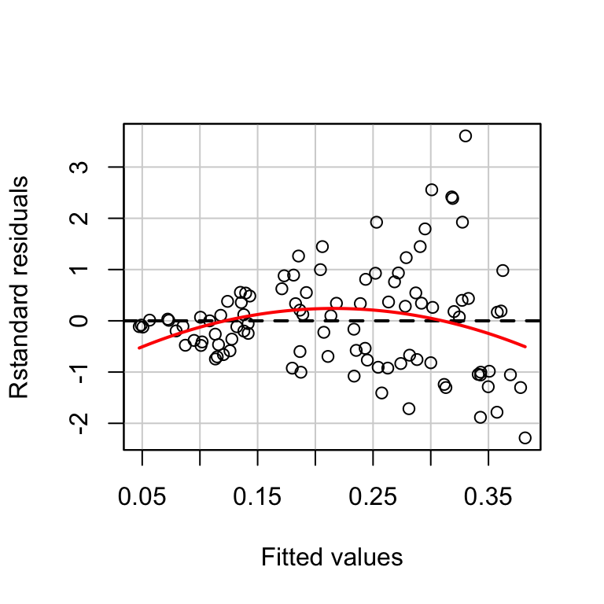

- Fitted: \(E(\bf Y|X = x) = \beta_0 + \beta_1 x_1 + \beta_2 x_2\)
- Truth: \(E(\bf Y|X = x) = \dfrac{|x_1|}{2 + (1.5 + x_2)^2}\)

## Example: Fuel consumption

How does fuel consumption vary over the 50 states and the District of Columbia?

| Variable | Description |
| --- | --- |
| Drivers | Number of licensed drivers in the state |
| FuelC | Gasoline sold for road use (thousands of gallons) |
| Income | Per person personal income (thousands of dollars) |
| Miles | Miles of Federal-aid highway miles in the state |
| Pop | Population age 16 and over |
| Tax | Gasoline state tax rate (cents per gallon) |
| MPC | Estimated miles driven per capita |
| Dlic | Number of licensed drivers in the state per 1,000 people age 16 and over (\(1000 \times Drivers/Pop\)) |
| Fuel | Fuel consumption (thousands of gallons) per 1,000 people age 16 and over (\(1000 \times FuelC/Pop\)) |

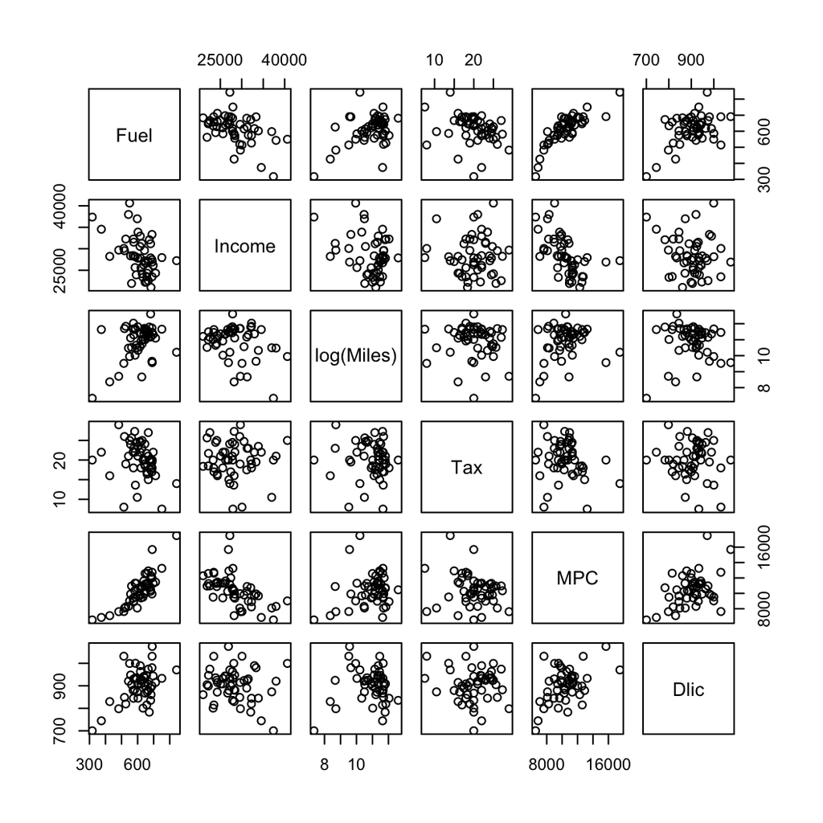

```r
pairs(Fuel ~ Income + log(Miles) + Tax + MPC + Dlic, data = fuel2001)
```

```r
mod1 <- lm(Fuel ~ Tax + Dlic + Income + log(Miles), data = fuel2001)
summary(mod1)
```

```
##
## Call:
## lm(formula = Fuel ~ Tax + Dlic + Income + log(Miles), data = fuel2001)
##
## Residuals:
##      Min       1Q   Median       3Q      Max
## -163.145  -33.039    5.895   31.989  183.499
##
## Coefficients:
##               Estimate Std. Error t value Pr(>|t|)
## (Intercept) 154.192845 194.906161   0.791 0.432938
## Tax          -4.227983   2.030121  -2.083 0.042873 *
## Dlic          0.471871   0.128513   3.672 0.000626 ***
## Income       -0.006135   0.002194  -2.797 0.007508 **
## log(Miles)   26.755176   9.337374   2.865 0.006259 **
## ---
## Signif. codes:  0 '***' 0.001 '**' 0.01 '*' 0.05 '.' 0.1 ' ' 1
##
## Residual standard error: 64.89 on 46 degrees of freedom
## Multiple R-squared:  0.5105, Adjusted R-squared:  0.4679
## F-statistic: 11.99 on 4 and 46 DF,  p-value: 9.331e-07
```

## Model checking: Linearity

**Effects of a violation**

- coefficients and fitted values are biased
- inferences not valid

**Diagnostics**

- Residual plots
  - residuals vs. fitted values
  - residuals vs. each predictor
  - residuals vs. hypothetical new predictors
- Added variable plots
- Marginal model plots
- Test for curvature

## Model checking: Linearity

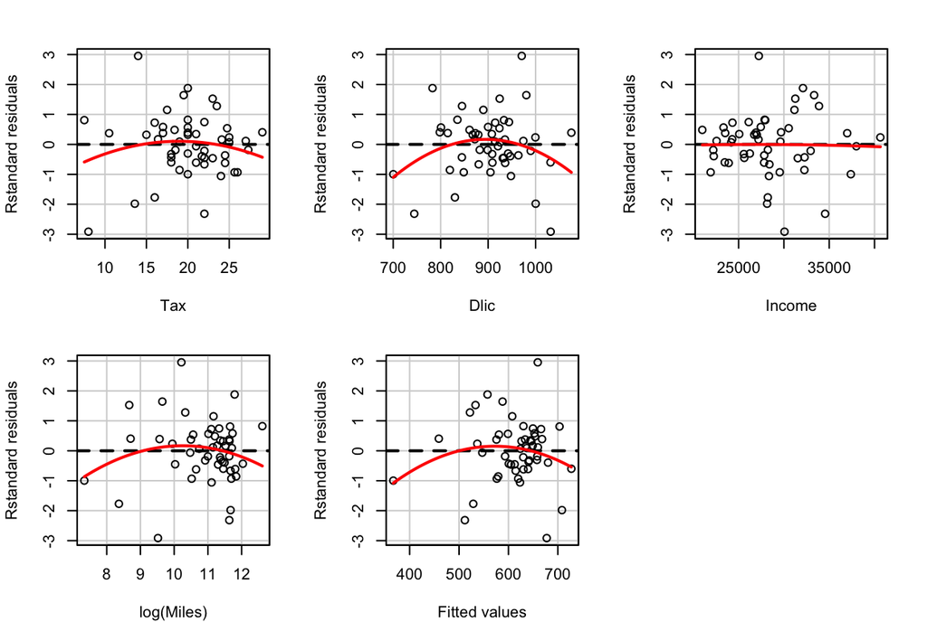

```r
residualPlots(mod1, layout = c(2, 3), type = "rstandard")
```

## Model checking: Linearity

### Added Variable Plots

- Display relationship of \(Y\) and \(X_j\) after adjusting for other variables
- Construction
  - \(e_j =\) residuals regressing \(Y\) on all \(X\)s except \(X_j\)
  - \(u_j=\) residuals regressing \(X_j\) on all other \(X\)s
  - Plot \(e_j\) vs. \(u_j\)

## Added Variable Plots in R

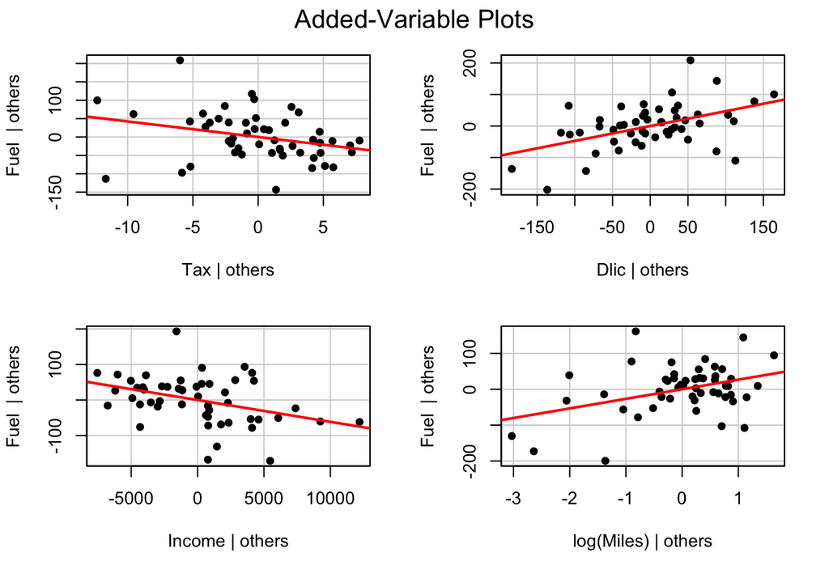

```r
avPlots(mod1, pch = 16)
```

## Model checking: Linearity

### Marginal Model Plots

- Idea: check whether \(E(Y | x_i)\) is well approximated by \(E(\widehat{Y} | x_i)\)
- Construction
  - Plot the response on the y-axis
  - Plot a predictor, or linear combination of the predictors (e.g. \(\widehat{y}_i\)) on the x-axis
  - Add a nonparametric smoother to the plot
  - Use the fitted values from the model to plot the conditional mean (via nonparametric smoother)

## Marginal Model Plots

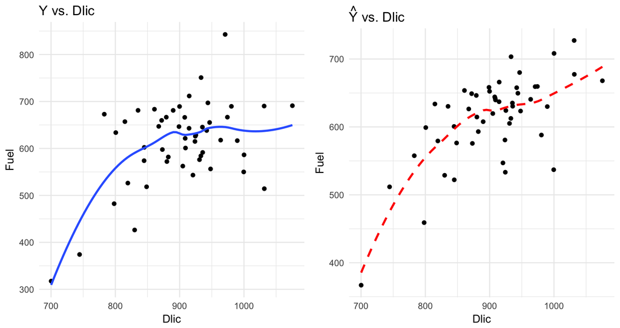

## Marginal Model Plots

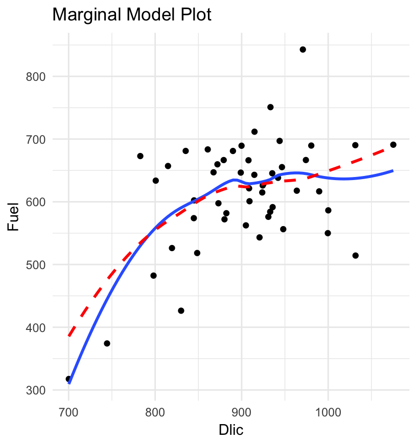

## Marginal Model Plots in R

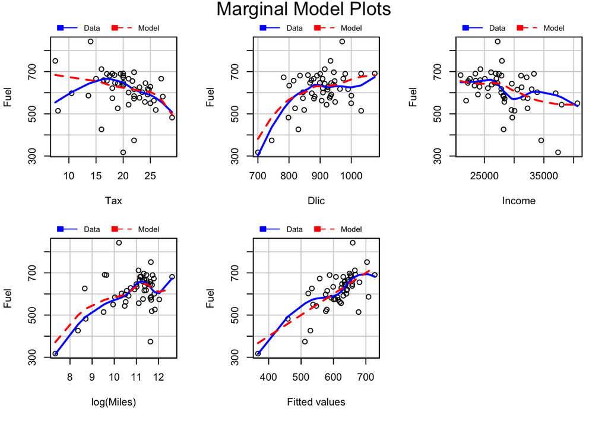

```r
mmps(mod1, layout = c(2,3))
```

## Marginal model vs. added variable plots

- **Marginal model plots**: are useful in checking to see that you're doing a good job of modeling the marginal relationship between a given predictor and the response.
- **Added variable plots**: assess how much variation in the response can be explained by a given predictor after the other predictors have already been taken into account (links to p-values).

## Model checking: Linearity

### Test for curvature

- If predictor \(U\) is in question, refit the regression with an added \(U^2\) term.
- Look at t-test for the slope associated with \(U^2\).

## Test for curvature in R

```r
# I only specified plot = FALSE for the slides
residualPlots(mod1, plot = FALSE)
```

```
##            Test stat Pr(>|t|)
## Tax           -1.077    0.287
## Dlic          -1.922    0.061
## Income        -0.084    0.933
## log(Miles)    -1.347    0.185
## Tukey test    -1.446    0.148
```

## Remedies for nonlinearity

- Nonlinear regression models (Grad school)
- Transformations of \(Y\)
- Transformations of \(X\)
- Polynomial regression

## Model checking: Constant variance

**Effects of a violation**

- Coefficients are unbiased
- \(se(\widehat{\beta}_i)\)s are biased (often too small \(\Longrightarrow\) CIs too narrow)

**Diagnostics**

- Residual plots
  - residuals vs. fitted values
  - residuals vs. each predictor
- Breusch-Pagan test

## Model checking: Constant variance

### Breusch-Pagan test

- \(H_0:\) constant error variance
- \(H_A:\) error variance changes with the level of the response (fitted values), or with a linear combination of predictors

```r
library(car) # if not loaded
ncvTest(mod1)
```

```
## Non-constant Variance Score Test
## Variance formula: ~ fitted.values
## Chisquare = 0.03196885    Df = 1     p = 0.858096
```

```r
ncvTest(mod1, ~ Tax + Dlic + Income + log(Miles))
```

```
## Non-constant Variance Score Test
## Variance formula: ~ Tax + Dlic + Income + log(Miles)
## Chisquare = 17.1249    Df = 4     p = 0.001827869
```

## Remedies for nonconstant variance

- Transformations of \(Y\)
  - \(\sqrt{Y}\) for counts
  - \(\log\) of positive #s with large range
  - \(\sin^{-1}(\sqrt{Y})\) or \(\log\left(\frac{Y}{1-Y} \right)\) for proportions (\(0 \le Y \le 1\))
- Weighted least squares (nice idea, see chapter 4)
- Use "sandwich estimator" for to obtain ses (inefficient)
- Use a generalized linear model

## Model checking: Uncorrelated errors

**Effects of a violation**

- coefficients are unbiased
- \(se(\widehat{\beta}_i)\)s are biased, often smaller than necessary
- inferences not valid

**Diagnostics**

- Residual plots
  - residuals vs. time (or other factor inducing correlation)
  - residuals vs. lagged residuals
  - examine residuals in clusters (e.g., family, school)
- Think about data collection process

## Model checking: Normal errors

**Effects of a violation**

- problems with prediction
- inference for coefficients OK in large samples
- inference for coefficients problematic in small samples

**Diagnostics**

- normal Q-Q plot
- case diagnostics (for outliers)

## Model checking: Normal errors

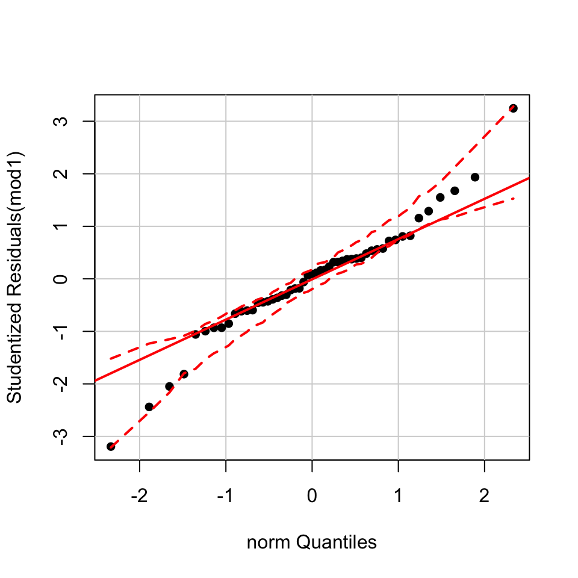

```r
qqPlot(mod1, dist = "norm", pch = 16, line = "quartiles")
```

## Remedies for non-normality

- Transformations
- Generalized linear models (Grad school or IS)

## Detecting outliers and influential points

## Standardized residuals

Recall that standardized residuals are calculated by dividing by their standard deviation

\[r_i = \dfrac{\widehat{e}_i}{ s \sqrt{1 - h_{ii}}}\]

Observations with large standardized residuals can be considered outliers.

Rule of thumb:

- \(|r_i|>2\) for small data sets
- \(|r_i|>4\) for large data sets

## Case diagnostics: Leverage

**Definition**

Pull off the diagonal elements of the hat matrix

\[\bf H = X (X^\prime X)^{-1} X^\prime\]

**Cutoff**

- \(2(k+1)/n\)
- \(3(k+1)/n\)
- Also a good idea to examine a histogram

## Case diagnostics: DFFITS

Measures the effect of the \(i^\text{th}\) case on the fitted value for \(Y_i\)

\[DFFITS_i = \dfrac{ \widehat{Y}_{i} - \widehat{Y}_{i(i)}}{\sqrt{\text{MSE}_{(i)} h_{ii}}}\]

where \(MSE_{(i)} = RSS_{(i)} / (n - p - 1)\)

**Cutoff**

- \(|DFFITS_i|>1\) considered large in small or medium samples
- \(|DFFITS_i|>2\sqrt{\frac{p+1}{n}}\) considered large in big samples
- Judge by relative standing

## Case diagnostics: Cook's D

Measures effect an observation has on all of the fitted values

\[D_i= \frac{\displaystyle\sum_{j=1}^n \left(\widehat{Y}_j - \widehat{Y}_{j(i)} \right)^2}{(p+1) \text{MSE}} = \dfrac{r^2_i}{p+1}\dfrac{h_{ii}}{1-h_{ii}}\]

**Cutoff**

- \(D_i > F_{p+1, n-p-1, 0.5}\) is of substantial concern
- Also can judge relative standing of \(D_i\)

## Case diagnostics: DFBETAS

Measures the effect of an observation on a single coefficient

\[DFBETAS_{k,i} = \dfrac{\widehat{\beta}_k - \widehat{\beta}_{k(i)}}{SE_{\beta_{(i)}}}\]

**Cutoff**

- \(DFBETA_i>1\) in small or medium samples
- \(DFBETA_i > 2/\sqrt{n}\) in large samples

## Case diagnostics in R

```r
case.infl <- influence.measures(mod1)

# print which observations "are" influential
which(apply(case.infl$is.inf, 1, any))
```

```
##  2  7  9 31 33 40 51
##  2  7  9 31 33 40 51
```

```r
# We can also call the measure individually
hatvalues(mod1)
cooks.distance(mod1)
dffits(mod1)
dfbetas(mod1)
```

## Detecting multicollinearity

## Example: Car seat position

**Research question:**

- Car designers would find it helpful to know where different drivers will position the seat depending on their size and age.
- Position can be measured by hip center

[figure not shown]

## Example: Car seat position

Researchers at the HuMoSim laboratory at the University of Michigan collected data on 38 drivers:

| Variable | Description |
| --- | --- |
| `Age` | Age (years) |
| `Weight` | Weight (lbs) |
| `HtShoes` | Height in shoes (cm) |
| `Ht` | Height in bare feet (cm) |
| `Seated` | Seated height (cm) |
| `Arm` | Lower arm length (cm) |
| `Thigh` | Thigh length (cm) |
| `Leg` | Lower leg length (cm) |
| `hipcenter` | horizontal distance of the midpoint of the hips from a fixed location in the car (mm) |

## Example: Car seat position

```
##   Age Weight HtShoes    Ht Seated  Arm Thigh  Leg hipcenter
## 1  46    180   187.2 184.9   95.2 36.1  45.3 41.3  -206.300
## 2  31    175   167.5 165.5   83.8 32.9  36.5 35.9  -178.210
## 3  23    100   153.6 152.2   82.9 26.0  36.6 31.0   -71.673
## 4  19    185   190.3 187.4   97.3 37.4  44.1 41.0  -257.720
## 5  23    159   178.0 174.1   93.9 29.5  40.1 36.9  -173.230
## 6  47    170   178.7 177.0   92.4 36.0  43.2 37.4  -185.150
```

## Example: Car seat position

```r
seatpos_mod <- lm(hipcenter ~ ., data = seatpos)
# the dot in the formula notation means 'all other variables'
broom::tidy(seatpos_mod)
```

```
##          term     estimate   std.error   statistic    p.value
## 1 (Intercept) 436.43212823 166.5716187  2.62008697 0.01384361
## 2         Age   0.77571620   0.5703288  1.36012113 0.18427175
## 3      Weight   0.02631308   0.3309704  0.07950283 0.93717877
## 4     HtShoes  -2.69240774   9.7530351 -0.27605845 0.78446097
## 5          Ht   0.60134458  10.1298739  0.05936348 0.95306980
## 6      Seated   0.53375170   3.7618942  0.14188376 0.88815293
## 7         Arm  -1.32806864   3.9001969 -0.34051323 0.73592450
## 8       Thigh  -1.14311888   2.6600237 -0.42974011 0.67056106
## 9         Leg  -6.43904627   4.7138601 -1.36598163 0.18244531
```

```r
broom::glance(seatpos_mod)
```

```
##   r.squared adj.r.squared    sigma statistic      p.value df    logLik
## 1 0.6865535     0.6000855 37.72029  7.939971 1.305773e-05  9 -186.7317
##        AIC      BIC deviance df.residual
## 1 393.4634 409.8392 41261.78          29
```

## Multicollinearity

- Definition: situation where 1+ predictors are "nearly" linearly related to the others.
- This is not a model violation, but we treat it like one because…
  - \(se(\widehat{\beta}_i)\)s are too big
  - it's difficult to interpret individual \(se(\widehat{\beta}_i)\)s
  - \(se(\widehat{\beta}_i)\)s change a lot with minor changes to the model/data (e.g., if we remove a case or a variable)

## Diagnosing Multicollinearity

- Examine scatterplot matrix
- Examine pairwise correlations between predictors
- Look for \(\widehat{\beta}_i\)s with unusual signs
- Notice great sensitivity
- Calculate the **Variance Inflation Factor (VIF)**

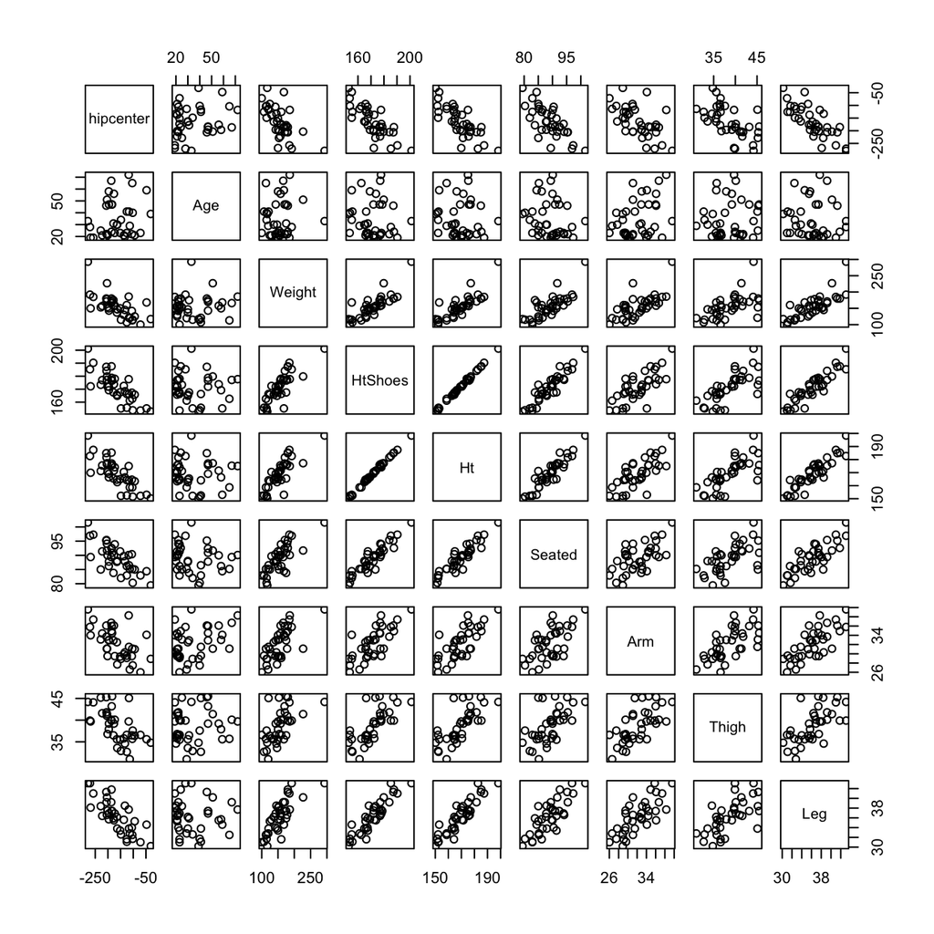

```r
cor(seatpos)
```

```
##              Age Weight HtShoes    Ht Seated   Arm  Thigh    Leg hipcenter
## Age        1.000  0.081  -0.079 -0.09  -0.17  0.36  0.091 -0.042      0.21
## Weight     0.081  1.000   0.828  0.83   0.78  0.70  0.573  0.784     -0.64
## HtShoes   -0.079  0.828   1.000  1.00   0.93  0.75  0.725  0.908     -0.80
## Ht        -0.090  0.829   0.998  1.00   0.93  0.75  0.735  0.910     -0.80
## Seated    -0.170  0.776   0.930  0.93   1.00  0.63  0.607  0.812     -0.73
## Arm        0.360  0.698   0.752  0.75   0.63  1.00  0.671  0.754     -0.59
## Thigh      0.091  0.573   0.725  0.73   0.61  0.67  1.000  0.650     -0.59
## Leg       -0.042  0.784   0.908  0.91   0.81  0.75  0.650  1.000     -0.79
## hipcenter  0.205 -0.640  -0.797 -0.80  -0.73 -0.59 -0.591 -0.787      1.00
```

## Variance Inflation Factor (VIF)

The variance of a given slope can be written

\[Var(\widehat{\beta}_j) = \dfrac{1}{1 - R^2_j} \times \dfrac{\sigma^2}{(n-1)s^2_{x_j}}\]

The first term is the VIF: \(\dfrac{1}{1 - R^2_j}\)

- \(\text{VIF}_j > 5\) suspicions begin (\(R^2_i > .8\))
- \(\text{VIF}_j > 10\) indicates a problem (\(R^2_i > .9\))
- \(\text{VIF}_j > 100\) indicates a big problem (\(R^2_i > .99\))

## Diagnosing Multicollinearity

```r
vif(seatpos_mod)
```

```
##        Age     Weight    HtShoes         Ht     Seated        Arm
##   1.997931   3.647030 307.429378 333.137832   8.951054   4.496368
##      Thigh        Leg
##   2.762886   6.694291
```

## Remedies for collinearity

- Use model only for prediction
- Drop highly correlated variables (USE CAUTION!)
- Create composite variables
- Find new cases that "break" the observed correlation (i.e., have a different pattern)

## Simplifying the model

```r
seatpos_mod2 <- lm(hipcenter ~ Age + Weight + Ht, data = seatpos)
summary(seatpos_mod2)
```

```
##
## Call:
## lm(formula = hipcenter ~ Age + Weight + Ht, data = seatpos)
##
## Residuals:
##     Min      1Q  Median      3Q     Max
## -91.526 -23.005   2.164  24.950  53.982
##
## Coefficients:
##               Estimate Std. Error t value Pr(>|t|)
## (Intercept) 528.297729 135.312947   3.904 0.000426 ***
## Age           0.519504   0.408039   1.273 0.211593
## Weight        0.004271   0.311720   0.014 0.989149
## Ht           -4.211905   0.999056  -4.216 0.000174 ***
## ---
## Signif. codes:  0 '***' 0.001 '**' 0.01 '*' 0.05 '.' 0.1 ' ' 1
##
## Residual standard error: 36.49 on 34 degrees of freedom
## Multiple R-squared:  0.6562, Adjusted R-squared:  0.6258
## F-statistic: 21.63 on 3 and 34 DF,  p-value: 5.125e-08
```

## Simplifying the model

```r
vif(seatpos_mod2)
```

```
##      Age   Weight       Ht
## 1.093018 3.457681 3.463303
```

## Diagnostics summary

## Diagnostics summary

Before drawing any conclusions from a regression model, we must be confident it is a valid way to model the data. Our model assumes:

- **Linearity**: the conditional mean of the response is a linear function of the predictors.
- The errors have **constant variance** and are **uncorrelated.**
- The errors are **normally distributed with mean zero**.

It's also sensible to build a model with:

- No highly influential points.
- Low multicollinearity.